By - Amaan Mohammed (121020994)

# **Football Analytics**

In the competitive world of professional football, the identification and development of talent go beyond simple scouting. Utilizing the FIFA 23 dataset, this project embarks on a detailed analysis to uncover the intricacies of player abilities and future potential through sophisticated data science techniques.

In this tutorial, we will be covering every stage of the Data Science Lifecycle:

1. **Data Collection**
2. **Data Processing**
3. **Exploratory analysis and Data Visualization**
4. **Model Training and Testing**
5. **Results Evaluation**

**The Importance of This Study:** In football, where competition is intense and stakes are high, having the ability to precisely predict and plan for player development offers clubs and managers a substantial advantage. This project not only seeks to refine the scouting process but also aims to deepen the understanding of player development, thereby enhancing decision-making in team formation and long-term player investment strategies.

By integrating classification and regression models, the project provides a dual approach to understanding and predicting player dynamics. The first model accurately categorizes players into their respective roles based on their skill sets, while the second anticipates their growth trajectories, setting the stage for the emergence of future football legends.

## **1. DATA COLLECTION**

This thesis leverages the extensive FIFA 23 dataset, which is built upon the scores assigned by scouts to player attributes, reflecting their on-field performances and capabilities.

**Import libraries**

We will start by importing all the Python libraries essential for data manipulation, analysis, and model development, equipping us to tackle the project's data-driven challenges effectively.

```python
#import all the necessary libraries
import pandas as pd
import seaborn as sns
import numpy as np
import matplotlib.pyplot as plt

from sklearn.preprocessing import LabelEncoder
from scipy.stats import f_oneway
from sklearn.ensemble import RandomForestClassifier
from sklearn.decomposition import PCA
from sklearn.preprocessing import StandardScaler
from sklearn.cluster import KMeans
from sklearn.metrics import silhouette_score
from sklearn.model_selection import train_test_split
from sklearn.linear_model import LogisticRegression
from sklearn.metrics import accuracy_score, classification_report
from sklearn.model_selection import cross_val_score
from sklearn.ensemble import RandomForestRegressor
from sklearn.metrics import mean_squared_error, r2_score
from sklearn.metrics import confusion_matrix, ConfusionMatrixDisplay
from sklearn.preprocessing import OneHotEncoder
from sklearn.compose import ColumnTransformer
from sklearn.pipeline import Pipeline
from mpl_toolkits.mplot3d import Axes3D
from sklearn.linear_model import LinearRegression
```

**Download and import data**

Here we are going to be downloading the Fifa23 csv file from kaggle which covers all attributes of a football player

```python
df = pd.read_csv('data.fifa23.csv', encoding='ISO-8859-1')
```

**Understanding the DF**

```python
df.head()
```

|  | ID | Name | FullName | Age | Height | Weight | PhotoUrl | Nationality | Overall | Potential | ... | Penalties | Composure | Marking | StandingTackle | SlidingTackle | GKDiving | GKHandling | GKKicking | GKPositioning | GKReflexes |
| --- | --- | --- | --- | --- | --- | --- | --- | --- | --- | --- | --- | --- | --- | --- | --- | --- | --- | --- | --- | --- | --- |
| 0 | 158023 | L. Messi | Lionel Messi | 35 | 169 | 67 | https://cdn.sofifa.net/players/158/023/23_60.png | Argentina | 91 | 91 | ... | 75 | 96 | 20 | 35 | 24 | 6 | 11 | 15 | 14 | 8 |
| 1 | 165153 | K. Benzema | Karim Benzema | 34 | 185 | 81 | https://cdn.sofifa.net/players/165/153/23_60.png | France | 91 | 91 | ... | 84 | 90 | 43 | 24 | 18 | 13 | 11 | 5 | 5 | 7 |
| 2 | 188545 | R. Lewandowski | Robert Lewandowski | 33 | 185 | 81 | https://cdn.sofifa.net/players/188/545/23_60.png | Poland | 91 | 91 | ... | 90 | 88 | 35 | 42 | 19 | 15 | 6 | 12 | 8 | 10 |
| 3 | 192985 | K. De Bruyne | Kevin De Bruyne | 31 | 181 | 70 | https://cdn.sofifa.net/players/192/985/23_60.png | Belgium | 91 | 91 | ... | 83 | 89 | 68 | 65 | 53 | 15 | 13 | 5 | 10 | 13 |
| 4 | 231747 | K. Mbappé | Kylian Mbappé | 23 | 182 | 73 | https://cdn.sofifa.net/players/231/747/23_60.png | France | 91 | 95 | ... | 80 | 88 | 26 | 34 | 32 | 13 | 5 | 7 | 11 | 6 |

5 rows × 60 columns

In the next step we try to get an understanding about the data and the type of values that we have. Additionally we also check for any missing values.

```python
#print data information
df.info()
```

```
<class 'pandas.core.frame.DataFrame'>
RangeIndex: 18539 entries, 0 to 18538
Data columns (total 60 columns):
 #   Column            Non-Null Count  Dtype
---  ------            --------------  -----
 0   ID                18539 non-null  int64
 1   Name              18539 non-null  object
 2   FullName          18539 non-null  object
 3   Age               18539 non-null  int64
 4   Height            18539 non-null  int64
 5   Weight            18539 non-null  int64
 6   PhotoUrl          18539 non-null  object
 7   Nationality       18539 non-null  object
 8   Overall           18539 non-null  int64
 9   Potential         18539 non-null  int64
```

[output cut: 52 more lines]

```python
# Check for missing values in each column
missing_values = df.isnull().sum()

# Print the number of missing values for each column
print("Number of missing values in each column:")
print(missing_values)
```

```
Number of missing values in each column:
ID                      0
Name                    0
FullName                0
Age                     0
Height                  0
Weight                  0
PhotoUrl                0
Nationality             0
Overall                 0
Potential               0
Growth                  0
TotalStats              0
BaseStats               0
BestPosition            0
Club                    0
ValueEUR                0
WageEUR                 0
ReleaseClause           0
ClubPosition           92
ContractUntil          92
ClubNumber             92
ClubJoined              0
NationalTeam            0
NationalPosition    17722
NationalNumber      17722
PreferredFoot           0
Crossing                0
Finishing               0
HeadingAccuracy         0
ShortPassing            0
Volleys                 0
Dribbling               0
Curve                   0
FKAccuracy              0
LongPassing             0
BallControl             0
Acceleration            0
SprintSpeed             0
Agility                 0
Reactions               0
Balance                 0
ShotPower               0
Jumping                 0
Stamina                 0
Strength                0
LongShots               0
Aggression              0
Interceptions           0
Positioning             0
Vision                  0
Penalties               0
Composure               0
Marking                 0
StandingTackle          0
SlidingTackle           0
GKDiving                0
GKHandling              0
GKKicking               0
GKPositioning           0
GKReflexes              0
dtype: int64
```

It seems like there are no null values in the columns that we require

```python
#print the number of rows and cols
print(df.shape)
```

```
(18539, 60)
```

```python
print(df.columns)
```

```
Index(['ID', 'Name', 'FullName', 'Age', 'Height', 'Weight', 'PhotoUrl',
       'Nationality', 'Overall', 'Potential', 'Growth', 'TotalStats',
       'BaseStats', 'BestPosition', 'Club', 'ValueEUR', 'WageEUR',
       'ReleaseClause', 'ClubPosition', 'ContractUntil', 'ClubNumber',
       'ClubJoined', 'NationalTeam', 'NationalPosition', 'NationalNumber',
       'PreferredFoot', 'Crossing', 'Finishing', 'HeadingAccuracy',
       'ShortPassing', 'Volleys', 'Dribbling', 'Curve', 'FKAccuracy',
       'LongPassing', 'BallControl', 'Acceleration', 'SprintSpeed', 'Agility',
       'Reactions', 'Balance', 'ShotPower', 'Jumping', 'Stamina', 'Strength',
       'LongShots', 'Aggression', 'Interceptions', 'Positioning', 'Vision',
       'Penalties', 'Composure', 'Marking', 'StandingTackle', 'SlidingTackle',
       'GKDiving', 'GKHandling', 'GKKicking', 'GKPositioning', 'GKReflexes'],
      dtype='object')
```

## **2. Data Processing**

```python
# List of columns to remove, adjust this list based on your review of the dataset
columns_to_remove = [
    'ID', 'Name', 'FullName', 'PhotoUrl','Nationality', 'Growth', 'TotalStats', 'Club', 'BaseStats', 'TotalStats', 'BaseStats', 'ValueEUR', 'WageEUR',
    'ContractUntil','ClubNumber', 'ReleaseClause', 'ReleaseClause','ClubPosition','ClubJoined', 'NationalTeam','NationalPosition', 'NationalNumber', 'PreferredFoot'
]
# Drop these columns
df.drop(columns=columns_to_remove, inplace=True, errors='ignore')  # 'errors=ignore' will ignore any errors if a column is not found
```

```python
#Updated columns list
print(df.columns)
```

```
Index(['Age', 'Height', 'Weight', 'Overall', 'Potential', 'BestPosition',
       'Crossing', 'Finishing', 'HeadingAccuracy', 'ShortPassing', 'Volleys',
       'Dribbling', 'Curve', 'FKAccuracy', 'LongPassing', 'BallControl',
       'Acceleration', 'SprintSpeed', 'Agility', 'Reactions', 'Balance',
       'ShotPower', 'Jumping', 'Stamina', 'Strength', 'LongShots',
       'Aggression', 'Interceptions', 'Positioning', 'Vision', 'Penalties',
       'Composure', 'Marking', 'StandingTackle', 'SlidingTackle', 'GKDiving',
       'GKHandling', 'GKKicking', 'GKPositioning', 'GKReflexes'],
      dtype='object')
```

```python
#no of cols in updated df
df.shape[1]
```

```
40
```

```python
df.head()
```

|  | Age | Height | Weight | Overall | Potential | BestPosition | Crossing | Finishing | HeadingAccuracy | ShortPassing | ... | Penalties | Composure | Marking | StandingTackle | SlidingTackle | GKDiving | GKHandling | GKKicking | GKPositioning | GKReflexes |
| --- | --- | --- | --- | --- | --- | --- | --- | --- | --- | --- | --- | --- | --- | --- | --- | --- | --- | --- | --- | --- | --- |
| 0 | 35 | 169 | 67 | 91 | 91 | CAM | 84 | 90 | 70 | 91 | ... | 75 | 96 | 20 | 35 | 24 | 6 | 11 | 15 | 14 | 8 |
| 1 | 34 | 185 | 81 | 91 | 91 | CF | 75 | 92 | 90 | 89 | ... | 84 | 90 | 43 | 24 | 18 | 13 | 11 | 5 | 5 | 7 |
| 2 | 33 | 185 | 81 | 91 | 91 | ST | 71 | 94 | 91 | 84 | ... | 90 | 88 | 35 | 42 | 19 | 15 | 6 | 12 | 8 | 10 |
| 3 | 31 | 181 | 70 | 91 | 91 | CM | 94 | 85 | 55 | 93 | ... | 83 | 89 | 68 | 65 | 53 | 15 | 13 | 5 | 10 | 13 |
| 4 | 23 | 182 | 73 | 91 | 95 | ST | 78 | 93 | 72 | 85 | ... | 80 | 88 | 26 | 34 | 32 | 13 | 5 | 7 | 11 | 6 |

5 rows × 40 columns

Our first classification model is designed to categorize players into one of four fundamental roles in football: **Midfielder, Forward, Defender, or Goalkeeper**. This simplifies understanding each player's best playing position by grouping specific positions under these broader categories, streamlining the process of identifying where a player might best contribute on the field.

```python
# Print unique values in the 'Best Position' column
unique_positions = df['BestPosition'].unique()
print(unique_positions)
```

```
['CAM' 'CF' 'ST' 'CM' 'RW' 'GK' 'CB' 'LW' 'CDM' 'LM' 'LB' 'RM' 'RB' 'LWB'
 'RWB']
```

```python
# Define the mapping from specific positions to general categories
position_mapping = {
    'CAM': 'Midfielder', 'CF': 'Forward', 'ST': 'Forward',
    'CM': 'Midfielder', 'RW': 'Forward', 'CB': 'Defender',
    'LW': 'Forward', 'CDM': 'Midfielder', 'LM': 'Midfielder',
    'LB': 'Defender', 'RM': 'Midfielder', 'RB': 'Defender',
    'LWB': 'Defender', 'RWB': 'Defender', 'GK': 'Goalkeeper'
}
```

```python
# Apply the mapping to the 'Best Position' column
df['BestPosition'] = df['BestPosition'].map(position_mapping)

# Check the updated unique values to ensure the mapping worked
print(df['BestPosition'].unique())
```

```
['Midfielder' 'Forward' 'Goalkeeper' 'Defender']
```

```python
df.head(10)
```

|  | Age | Height | Weight | Overall | Potential | BestPosition | Crossing | Finishing | HeadingAccuracy | ShortPassing | ... | Penalties | Composure | Marking | StandingTackle | SlidingTackle | GKDiving | GKHandling | GKKicking | GKPositioning | GKReflexes |
| --- | --- | --- | --- | --- | --- | --- | --- | --- | --- | --- | --- | --- | --- | --- | --- | --- | --- | --- | --- | --- | --- |
| 0 | 35 | 169 | 67 | 91 | 91 | Midfielder | 84 | 90 | 70 | 91 | ... | 75 | 96 | 20 | 35 | 24 | 6 | 11 | 15 | 14 | 8 |
| 1 | 34 | 185 | 81 | 91 | 91 | Forward | 75 | 92 | 90 | 89 | ... | 84 | 90 | 43 | 24 | 18 | 13 | 11 | 5 | 5 | 7 |
| 2 | 33 | 185 | 81 | 91 | 91 | Forward | 71 | 94 | 91 | 84 | ... | 90 | 88 | 35 | 42 | 19 | 15 | 6 | 12 | 8 | 10 |
| 3 | 31 | 181 | 70 | 91 | 91 | Midfielder | 94 | 85 | 55 | 93 | ... | 83 | 89 | 68 | 65 | 53 | 15 | 13 | 5 | 10 | 13 |
| 4 | 23 | 182 | 73 | 91 | 95 | Forward | 78 | 93 | 72 | 85 | ... | 80 | 88 | 26 | 34 | 32 | 13 | 5 | 7 | 11 | 6 |
| 5 | 30 | 175 | 71 | 90 | 90 | Forward | 80 | 93 | 59 | 84 | ... | 86 | 92 | 38 | 43 | 41 | 14 | 14 | 9 | 11 | 14 |
| 6 | 30 | 199 | 96 | 90 | 91 | Goalkeeper | 14 | 14 | 13 | 33 | ... | 27 | 66 | 20 | 18 | 16 | 84 | 89 | 75 | 89 | 90 |
| 7 | 36 | 193 | 93 | 90 | 90 | Goalkeeper | 15 | 13 | 25 | 60 | ... | 47 | 70 | 17 | 10 | 11 | 87 | 88 | 91 | 91 | 88 |
| 8 | 37 | 187 | 83 | 90 | 90 | Forward | 80 | 93 | 90 | 80 | ... | 90 | 95 | 24 | 32 | 24 | 7 | 11 | 15 | 14 | 11 |
| 9 | 30 | 193 | 92 | 90 | 90 | Defender | 53 | 52 | 87 | 79 | ... | 62 | 90 | 92 | 92 | 86 | 13 | 10 | 13 | 11 | 11 |

10 rows × 40 columns

## **3. Exploratory analysis and Data visualization**

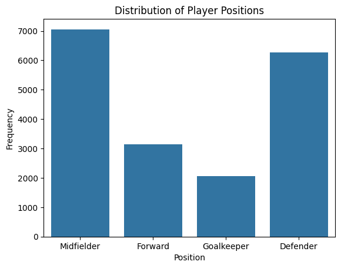

```python
# Distribution of Player Positions
sns.countplot(x='BestPosition', data=df)
plt.title('Distribution of Player Positions')
plt.xlabel('Position')
plt.ylabel('Frequency')
plt.show()
```

We will be combining all the Goalkeeper stats under one column since it does not effect our classification all that much.

```python
# Assign weights based on your understanding of the importance of each attribute
weights = {'GKDiving': 0.3, 'GKHandling': 0.3, 'GKKicking': 0.1, 'GKPositioning': 0.1, 'GKReflexes': 0.2}

# Create the weighted sum
df['GKScore'] = df.apply(lambda row: sum(row[attr] * weight for attr, weight in weights.items()), axis=1)
```

```python
# List of goalkeeper attributes to be removed
goalkeeper_attributes = ['GKDiving', 'GKHandling', 'GKKicking', 'GKPositioning', 'GKReflexes']

# Drop these attributes from the dataframe
df.drop(columns=goalkeeper_attributes, inplace=True)

# Verify the remaining columns
print(df.columns)
```

```
Index(['Age', 'Height', 'Weight', 'Overall', 'Potential', 'BestPosition',
       'Crossing', 'Finishing', 'HeadingAccuracy', 'ShortPassing', 'Volleys',
       'Dribbling', 'Curve', 'FKAccuracy', 'LongPassing', 'BallControl',
       'Acceleration', 'SprintSpeed', 'Agility', 'Reactions', 'Balance',
       'ShotPower', 'Jumping', 'Stamina', 'Strength', 'LongShots',
       'Aggression', 'Interceptions', 'Positioning', 'Vision', 'Penalties',
       'Composure', 'Marking', 'StandingTackle', 'SlidingTackle', 'GKScore'],
      dtype='object')
```

```python
# Summary statistics for numeric features
print(df.describe())
```

```
                Age        Height        Weight       Overall     Potential  \
count  18539.000000  18539.000000  18539.000000  18539.000000  18539.000000
mean      25.240412    181.550839     75.173904     65.852042     71.016668
std        4.718163      6.858097      7.013593      6.788353      6.192866
min       16.000000    155.000000     49.000000     47.000000     48.000000
25%       21.000000    177.000000     70.000000     62.000000     67.000000
50%       25.000000    182.000000     75.000000     66.000000     71.000000
75%       29.000000    186.000000     80.000000     70.000000     75.000000
max       44.000000    206.000000    105.000000     91.000000     95.000000

           Crossing     Finishing  HeadingAccuracy  ShortPassing  \
count  18539.000000  18539.000000     18539.000000  18539.000000
mean      49.476833     46.255300        51.846755     59.072226
std       17.887405     19.623881        17.318947     14.287698
min        6.000000      3.000000         5.000000     10.000000
25%       39.000000     31.000000        44.000000     55.000000
50%       54.000000     50.000000        55.000000     62.000000
75%       63.000000     62.000000        64.000000     68.000000
max       94.000000     94.000000        93.000000     93.000000

            Volleys  ...    Aggression  Interceptions   Positioning  \
count  18539.000000  ...  18539.000000   18539.000000  18539.000000
mean      42.513944  ...     55.668537      46.853282     50.520362
std       17.635249  ...     16.905505      20.666647     19.660034
min        3.000000  ...     10.000000       3.000000      2.000000
25%       30.000000  ...     45.000000      26.000000     40.000000
50%       44.000000  ...     58.000000      54.000000     56.000000
75%       56.000000  ...     68.000000      64.000000     64.000000
max       90.000000  ...     95.000000      91.000000     96.000000

             Vision     Penalties     Composure       Marking  StandingTackle  \
count  18539.000000  18539.000000  18539.000000  18539.000000    18539.000000
mean      54.191542     47.994444     58.036625     46.747505       48.399159
std       13.478006     15.730026     12.036272     20.350228       21.191644
min       10.000000      6.000000     13.000000      3.000000        6.000000
25%       45.000000     39.000000     51.000000     29.000000       28.000000
50%       56.000000     49.000000     59.000000     53.000000       56.000000
75%       64.000000     60.000000     66.000000     63.000000       66.000000
max       94.000000     92.000000     96.000000     92.000000       93.000000

       SlidingTackle       GKScore
count   18539.000000  18539.000000
mean       46.264146     16.289066
std        20.701146     17.129892
min         6.000000      2.000000
25%        26.000000      9.400000
50%        53.000000     10.500000
75%        63.000000     11.900000
max        90.000000     88.300000

[8 rows x 35 columns]
```

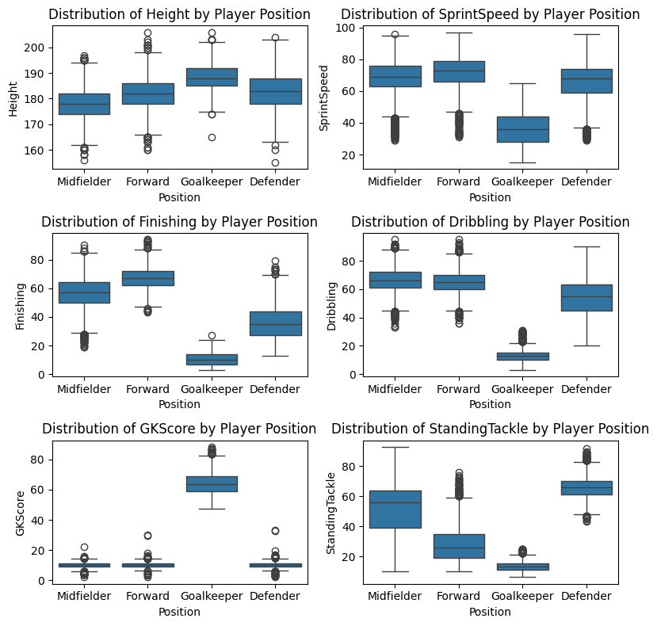

```python
features_to_plot = ['Height', 'SprintSpeed', 'Finishing', 'Dribbling', 'GKScore', 'StandingTackle' ]

# Create a figure with subplots
plt.figure(figsize=(8, 8))  # Adjust the size to fit all subplots nicely

for i, feature in enumerate(features_to_plot, 1):
    plt.subplot(3, 2, i)  # 1 row, 5 columns, ith subplot
    sns.boxplot(x='BestPosition', y=feature, data=df)
    plt.title(f'Distribution of {feature} by Player Position')
    plt.xlabel('Position')
    plt.ylabel(feature)

plt.tight_layout()  # Adjust subplots to fit into figure area.
plt.show()
```

The box plots visualize the distribution of various player attributes by position. For instance, goalkeepers generally exhibit lower scores in outfield attributes like dribbling and finishing but higher in GKScore. These visualizations are crucial for understanding position-specific performance metrics and highlight the specialized skills needed for each role on the field.

```python
df.head(10)
```

|  | Age | Height | Weight | Overall | Potential | BestPosition | Crossing | Finishing | HeadingAccuracy | ShortPassing | ... | Aggression | Interceptions | Positioning | Vision | Penalties | Composure | Marking | StandingTackle | SlidingTackle | GKScore |
| --- | --- | --- | --- | --- | --- | --- | --- | --- | --- | --- | --- | --- | --- | --- | --- | --- | --- | --- | --- | --- | --- |
| 0 | 35 | 169 | 67 | 91 | 91 | Midfielder | 84 | 90 | 70 | 91 | ... | 44 | 40 | 93 | 94 | 75 | 96 | 20 | 35 | 24 | 9.6 |
| 1 | 34 | 185 | 81 | 91 | 91 | Forward | 75 | 92 | 90 | 89 | ... | 63 | 39 | 92 | 89 | 84 | 90 | 43 | 24 | 18 | 9.6 |
| 2 | 33 | 185 | 81 | 91 | 91 | Forward | 71 | 94 | 91 | 84 | ... | 81 | 49 | 94 | 81 | 90 | 88 | 35 | 42 | 19 | 10.3 |
| 3 | 31 | 181 | 70 | 91 | 91 | Midfielder | 94 | 85 | 55 | 93 | ... | 75 | 66 | 88 | 94 | 83 | 89 | 68 | 65 | 53 | 12.5 |
| 4 | 23 | 182 | 73 | 91 | 95 | Forward | 78 | 93 | 72 | 85 | ... | 64 | 38 | 92 | 83 | 80 | 88 | 26 | 34 | 32 | 8.4 |
| 5 | 30 | 175 | 71 | 90 | 90 | Forward | 80 | 93 | 59 | 84 | ... | 63 | 55 | 92 | 85 | 86 | 92 | 38 | 43 | 41 | 13.2 |
| 6 | 30 | 199 | 96 | 90 | 91 | Goalkeeper | 14 | 14 | 13 | 33 | ... | 23 | 15 | 13 | 44 | 27 | 66 | 20 | 18 | 16 | 86.3 |
| 7 | 36 | 193 | 93 | 90 | 90 | Goalkeeper | 15 | 13 | 25 | 60 | ... | 29 | 30 | 12 | 70 | 47 | 70 | 17 | 10 | 11 | 88.3 |
| 8 | 37 | 187 | 83 | 90 | 90 | Forward | 80 | 93 | 90 | 80 | ... | 63 | 29 | 95 | 76 | 90 | 95 | 24 | 32 | 24 | 10.5 |
| 9 | 30 | 193 | 92 | 90 | 90 | Defender | 53 | 52 | 87 | 79 | ... | 85 | 90 | 47 | 65 | 62 | 90 | 92 | 92 | 86 | 11.5 |

10 rows × 36 columns

```python
# Performing ANOVA test
attributes = df.select_dtypes(include=[np.number]).columns

anova_results = {}

for attribute in attributes:
    groups = df.groupby('BestPosition')[attribute].apply(list)
    f_val, p_val = f_oneway(*groups)
    anova_results[attribute] = (f_val, p_val)

# Output the results
for attr, (f_val, p_val) in anova_results.items():
    print(f"ANOVA results for {attr}: F-Statistic = {f_val}, P-value = {p_val}")
```

```
ANOVA results for Age: F-Statistic = 85.89316973054503, P-value = 3.44477493379528e-55
ANOVA results for Height: F-Statistic = 1977.338418118556, P-value = 0.0
ANOVA results for Weight: F-Statistic = 1606.395870289693, P-value = 0.0
ANOVA results for Overall: F-Statistic = 33.62164905229252, P-value = 1.1580499370168375e-21
ANOVA results for Potential: F-Statistic = 68.04920091265669, P-value = 9.309488074991493e-44
ANOVA results for Crossing: F-Statistic = 7232.611270553262, P-value = 0.0
ANOVA results for Finishing: F-Statistic = 17609.785488957627, P-value = 0.0
ANOVA results for HeadingAccuracy: F-Statistic = 13306.417175130446, P-value = 0.0
ANOVA results for ShortPassing: F-Statistic = 11052.519816278864, P-value = 0.0
ANOVA results for Volleys: F-Statistic = 11335.215468523496, P-value = 0.0
ANOVA results for Dribbling: F-Statistic = 17894.161519014622, P-value = 0.0
ANOVA results for Curve: F-Statistic = 7182.701855235264, P-value = 0.0
ANOVA results for FKAccuracy: F-Statistic = 6498.861108717041, P-value = 0.0
ANOVA results for LongPassing: F-Statistic = 6655.823382371858, P-value = 0.0
ANOVA results for BallControl: F-Statistic = 18821.278552965647, P-value = 0.0
ANOVA results for Acceleration: F-Statistic = 5636.990041633895, P-value = 0.0
ANOVA results for SprintSpeed: F-Statistic = 5390.225529330102, P-value = 0.0
ANOVA results for Agility: F-Statistic = 5221.068701640989, P-value = 0.0
ANOVA results for Reactions: F-Statistic = 145.35087933978164, P-value = 4.2333344925706214e-93
ANOVA results for Balance: F-Statistic = 4267.920953651766, P-value = 0.0
ANOVA results for ShotPower: F-Statistic = 3123.741427823117, P-value = 0.0
ANOVA results for Jumping: F-Statistic = 1203.0506092157184, P-value = 0.0
ANOVA results for Stamina: F-Statistic = 7802.524913028889, P-value = 0.0
ANOVA results for Strength: F-Statistic = 1202.52513254717, P-value = 0.0
ANOVA results for LongShots: F-Statistic = 11446.79629256444, P-value = 0.0
ANOVA results for Aggression: F-Statistic = 5425.334444778948, P-value = 0.0
ANOVA results for Interceptions: F-Statistic = 10822.983243129685, P-value = 0.0
ANOVA results for Positioning: F-Statistic = 14975.302462591493, P-value = 0.0
ANOVA results for Vision: F-Statistic = 4253.59784031558, P-value = 0.0
ANOVA results for Penalties: F-Statistic = 11430.809402401155, P-value = 0.0
ANOVA results for Composure: F-Statistic = 2526.274017882351, P-value = 0.0
ANOVA results for Marking: F-Statistic = 12530.536748578153, P-value = 0.0
ANOVA results for StandingTackle: F-Statistic = 14033.562568689178, P-value = 0.0
ANOVA results for SlidingTackle: F-Statistic = 15029.148325423499, P-value = 0.0
ANOVA results for GKScore: F-Statistic = 222418.33975984956, P-value = 0.0
```

The ANOVA results showing very low p-values for most attributes indicate significant differences in these attributes across different player positions. This suggests that certain skills and physical characteristics are uniquely significant in determining the most suitable playing position for a player. For instance, high F-statistics for attributes like Crossing, Finishing, and Sprint Speed support the idea that these skills vary greatly among positions and are critical in defining a player's role on the field.

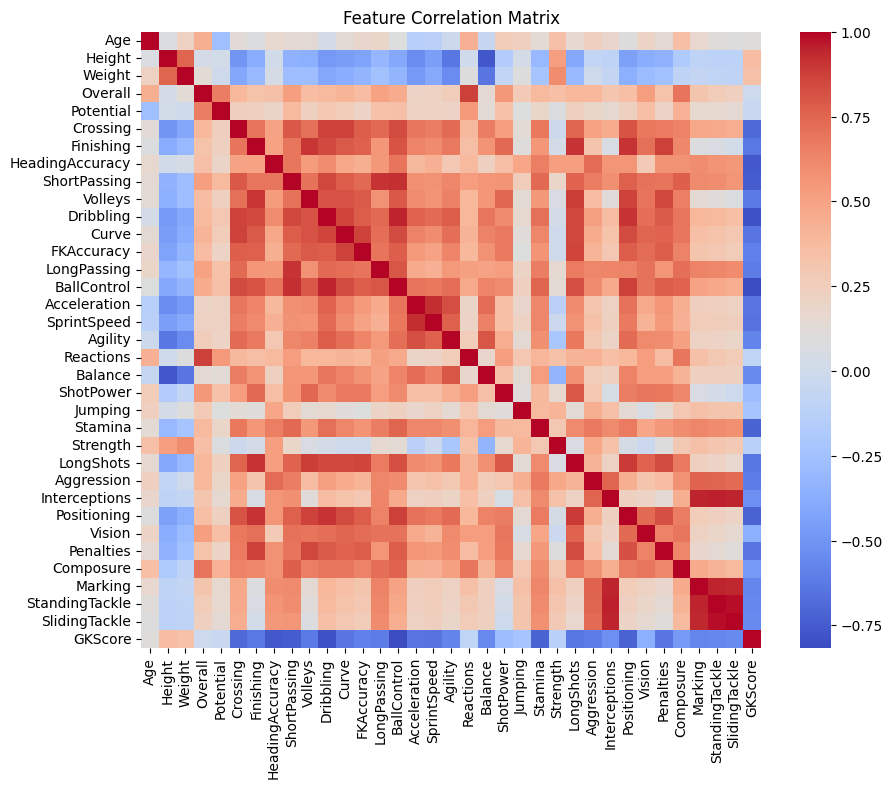

```python
# Calculate correlation matrix
corr_matrix = df.select_dtypes(include=[np.number]).corr()

# Plot the heatmap
plt.figure(figsize=(10, 8))
sns.heatmap(corr_matrix, annot=False, cmap='coolwarm')
plt.title('Feature Correlation Matrix')
plt.show()
```

The correlation matrix provides valuable insights into how player attributes are interlinked. Key conclusions include:

1. Attributes like 'Overall' and 'Potential' have strong positive correlations with skills such as 'Reactions' and 'Composure', suggesting that these qualities are significant indicators of a player’s current and future abilities.
2. Negative correlations, such as those between 'Age' and physical attributes like 'SprintSpeed' and 'Agility', highlight the expected decline in physical performance as players age.
3. The strong interrelationships among technical skills (e.g., 'BallControl', 'Dribbling', 'Passing') indicate clusters of skills that commonly improve together, which could be pivotal in player training and development.

Next we use **feature importance** in a Random Forest model to identify the significance of each feature in predicting the target, which is the 'BestPosition'

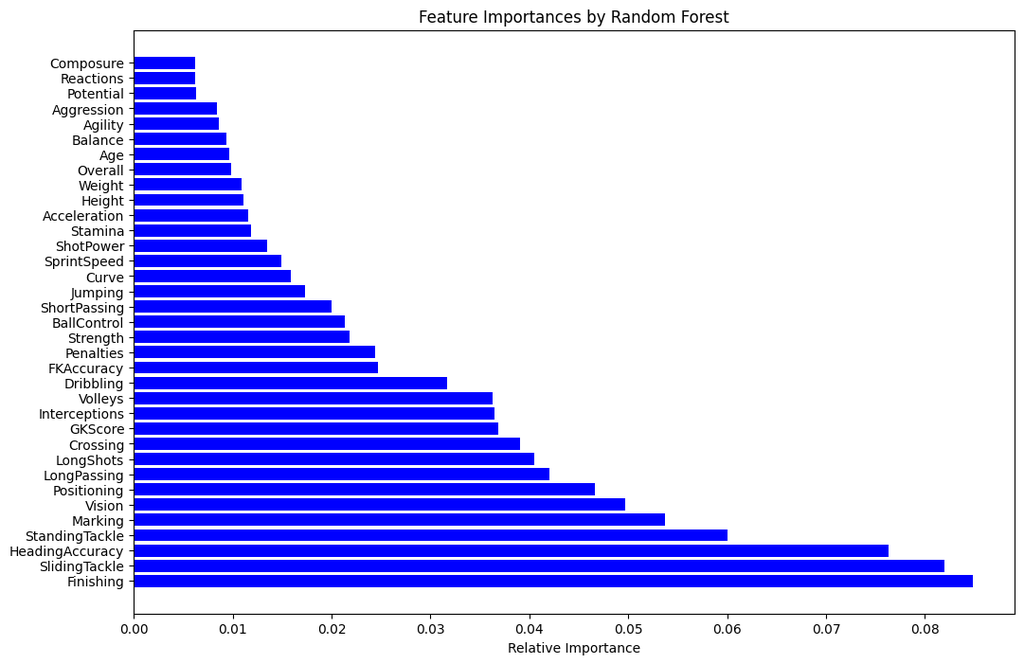

```python
# Assuming you've already prepared your dataset 'df' and split into features 'X' and target 'y'
X = df.drop('BestPosition', axis=1)  # your features
y = df['BestPosition']  # your target

# Fit Random Forest
forest = RandomForestClassifier(n_estimators=500, random_state=150)
forest.fit(X, y)

# Get feature importances
importances = forest.feature_importances_

# Visualize feature importances
features = X.columns
indices = np.argsort(importances)[::-1]

plt.figure(figsize=(12, 8))
plt.title('Feature Importances by Random Forest')
plt.barh(range(len(indices)), importances[indices], color='b', align='center')
plt.yticks(range(len(indices)), [features[i] for i in indices])
plt.xlabel('Relative Importance')
plt.show()
```

The chart lists the features sorted by their importance as determined by a Random Forest model. Finishing, SlidingTackle, and HeadingAccuracy are the top three features, indicating they are the most significant predictors in the model. This insight can help focus on the most influential attributes for player position determination.

**Some more visualization**

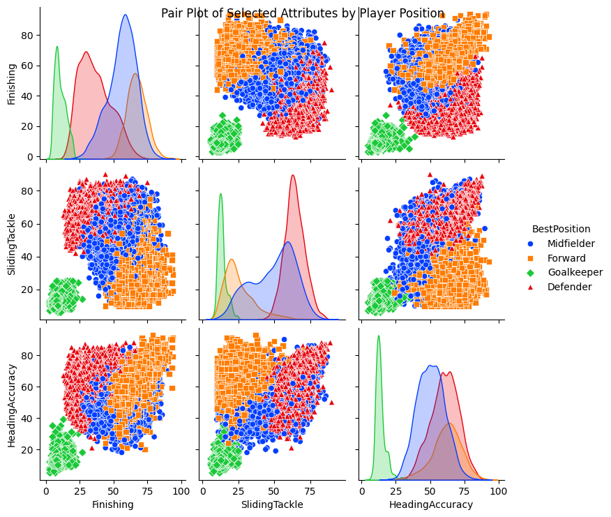

```python
# Select a subset of attributes that are of most interest
selected_attributes = ['Finishing', 'SlidingTackle', 'HeadingAccuracy']

# Create a pair plot
sns.pairplot(df[selected_attributes + ['BestPosition']], hue='BestPosition', palette='bright', markers=["o", "s", "D", "^"])
plt.suptitle('Pair Plot of Selected Attributes by Player Position', size=12)
plt.show()
```

These pair plots show the distribution and relationships of finishing, sliding tackle, and heading accuracy across player positions in football. The density plots highlight the varying skills levels typical for midfielders, forwards, defenders, and goalkeepers, suggesting specific attribute strengths necessary for each role. Scatter plots further illuminate how these skills correlate, providing insights into player versatility and specialization within their positions. This visualization helps in understanding which attributes are pivotal for performance in each football role.

The next very crucial step for us is to do the **principal component analysis**. PCA was used here to reduce the dimensionality of the dataset, simplifying the model without losing critical information, which is crucial for effectively training machine learning models on complex datasets like FIFA player attributes.

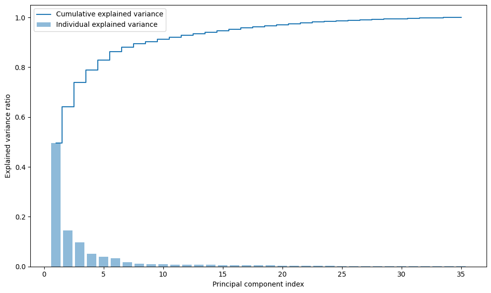

```python
features = df.drop(['BestPosition'], axis=1)  # Exclude the target variable
features_scaled = StandardScaler().fit_transform(features)  # Standardize the data

# Initialize PCA and fit the scaled data
pca = PCA()
components = pca.fit_transform(features_scaled)

# Check how much variance is explained by each component
explained_variance = pca.explained_variance_ratio_
cumulative_variance = pca.explained_variance_ratio_.cumsum()

# Code for plotting explained variance and cumulative explained variance
plt.figure(figsize=(10, 6))
plt.bar(range(1, len(explained_variance) + 1), explained_variance, alpha=0.5, align='center', label='Individual explained variance')
plt.step(range(1, len(cumulative_variance) + 1), cumulative_variance, where='mid', label='Cumulative explained variance')
plt.ylabel('Explained variance ratio')
plt.xlabel('Principal component index')
plt.legend(loc='best')
plt.tight_layout()  # Adjust layout to prevent overlap
plt.show()  # Display the plot

# Create a DataFrame of the principal components
pca_df = pd.DataFrame(data=components, columns=[f'PC{i+1}' for i in range(len(explained_variance))])
pca_df['BestPosition'] = df['BestPosition']  # Add the target variable back
```

```python
features = df.drop(['BestPosition'], axis=1)  # Exclude the target variable for PCA
features_scaled = StandardScaler().fit_transform(features)  # Standardize the data

# Initialize PCA and fit the scaled data
pca = PCA(n_components=5)  # Adjust components as needed
principal_components = pca.fit_transform(features_scaled)

# Create a DataFrame of the principal components
principal_df = pd.DataFrame(data = principal_components, columns = ['PC1', 'PC2', 'PC3', 'PC4', 'PC5' ])
principal_df['BestPosition'] = df['BestPosition']  # Add the target variable back

# Check the DataFrame to ensure it's correctly set up
print(principal_df.head())
```

```
        PC1       PC2       PC3       PC4       PC5 BestPosition
0  9.647041 -3.101347  5.046118  3.259364  0.099789   Midfielder
1  8.414209 -0.510291  6.599923  0.723947  1.571875      Forward
2  8.621627  0.018939  6.528507  0.380630  1.471769      Forward
3  9.754575  0.287391  4.394046  3.211704  0.022125   Midfielder
4  8.866135 -1.868415  4.756022  1.720170  3.716055      Forward
```

The above code selects five principal components to represent the data, effectively summarizing multiple player attributes into fewer, composite indicators. This transformed data is then compiled into a new DataFrame This approach aids in identifying key patterns and simplifies complex, multi-dimensional data into a more manageable form for further analysis or visualization.

```python
features = df.drop(['BestPosition'], axis=1)
features_scaled = StandardScaler().fit_transform(features)

pca = PCA(n_components=5)
pca.fit(features_scaled)

# The loading scores for each principal component
loadings = pd.DataFrame(pca.components_.T, columns=['PC1', 'PC2', 'PC3', 'PC4', 'PC5'], index=features.columns)
print(loadings)
```

```
                      PC1       PC2       PC3       PC4       PC5
Age              0.038455  0.127843  0.240724  0.011261 -0.539626
Height          -0.109790  0.210798  0.250006 -0.213288  0.169944
Weight          -0.086457  0.212398  0.290503 -0.221326  0.095258
Overall          0.122812  0.129286  0.319288  0.333539  0.122374
Potential        0.082072  0.039094  0.168309  0.369847  0.544908
Crossing         0.213004 -0.040147 -0.063232  0.059400 -0.075093
Finishing        0.196691 -0.169682  0.123937 -0.173224  0.005862
HeadingAccuracy  0.164172  0.189033  0.014010 -0.310879  0.125581
ShortPassing     0.222118  0.067767 -0.000536  0.042652 -0.002064
Volleys          0.198413 -0.135346  0.132224 -0.156061 -0.034484
Dribbling        0.225598 -0.077969 -0.026395 -0.051454  0.052463
Curve            0.214096 -0.086540  0.034835  0.019386 -0.101430
FKAccuracy       0.200744 -0.085935  0.059733 -0.004658 -0.197097
LongPassing      0.201285  0.096108 -0.007487  0.151379 -0.114404
BallControl      0.229912 -0.006524 -0.004792 -0.048269  0.051520
Acceleration     0.176054 -0.135812 -0.153372 -0.032745  0.264283
SprintSpeed      0.170913 -0.102235 -0.134274 -0.082920  0.312711
Agility          0.184675 -0.165003 -0.109588  0.076002  0.079792
Reactions        0.127860  0.131306  0.293682  0.290041  0.058992
Balance          0.165612 -0.164929 -0.191243  0.134995 -0.018496
ShotPower        0.159207 -0.090083  0.294044 -0.004227 -0.069977
Jumping          0.068159  0.183990  0.029343 -0.142864  0.154909
Stamina          0.193470  0.104671 -0.088031 -0.082432  0.056846
Strength         0.033270  0.297074  0.221093 -0.300044  0.099903
LongShots        0.210108 -0.114770  0.110156 -0.100494 -0.090924
Aggression       0.156497  0.258574 -0.049225 -0.078649 -0.024438
Interceptions    0.125512  0.317710 -0.188151  0.110653 -0.087752
Positioning      0.214729 -0.117710  0.044112 -0.122249 -0.004089
Vision           0.182558 -0.094716  0.150924  0.189041 -0.124847
Penalties        0.192829 -0.112662  0.114591 -0.197293 -0.044146
Composure        0.192413  0.078148  0.176267  0.108295 -0.011016
Marking          0.131230  0.312608 -0.187892  0.083502 -0.071800
StandingTackle   0.125837  0.310326 -0.219234  0.092954 -0.060537
SlidingTackle    0.117916  0.311796 -0.235427  0.100219 -0.057549
GKScore         -0.188271 -0.031639  0.210410  0.289613 -0.048818
```

This matrix shows the loading scores for each principal component derived from our dataset, which quantify how much each attribute contributes to the principal components. Here, components like PC1 and PC2 may be interpreted as capturing the most variance across the features.

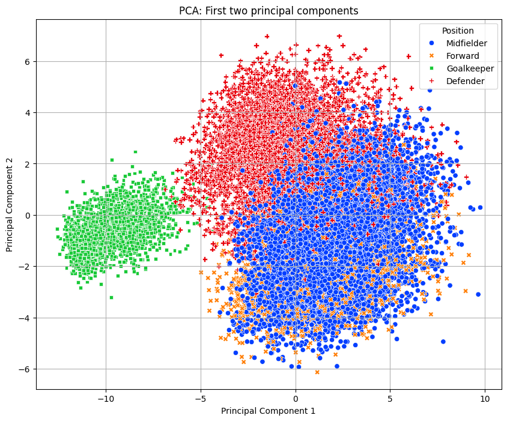

```python
plt.figure(figsize=(10, 8))
sns.scatterplot(x='PC1', y='PC2', hue='BestPosition', data=principal_df, style='BestPosition', palette='bright')
plt.title('PCA: First two principal components')
plt.xlabel('Principal Component 1')
plt.ylabel('Principal Component 2')
plt.legend(title='Position')
plt.grid(True)
plt.show()
```

The scatter plot above provides a clear visualization of the first two principal components segmented by player positions.There is some clear distinction between groups, however there is also some overlap with the Midfielder and Forward positions.

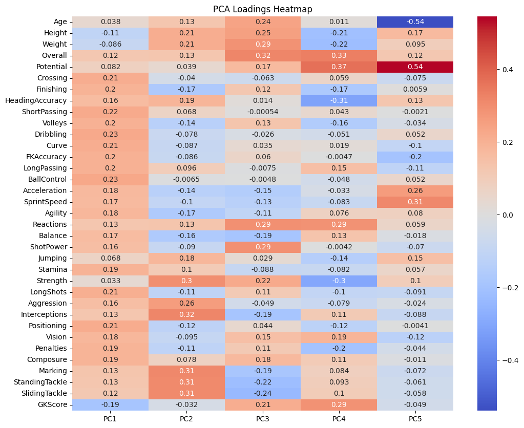

```python
plt.figure(figsize=(12, 10))
sns.heatmap(loadings, annot=True, cmap='coolwarm', center=0)
plt.title('PCA Loadings Heatmap')
plt.show()
```

The heatmap of PCA loadings visually captures the influence of various player attributes on the five principal components derived from the dataset, where red and blue signify positive and negative influences, respectively.

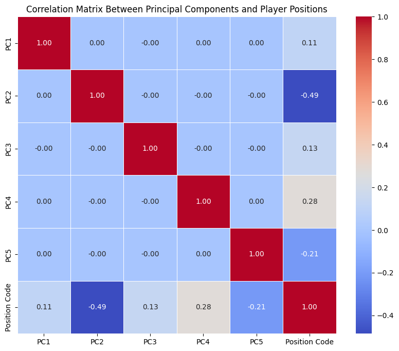

```python
# Step 1: Encode the 'Best Position' column
label_encoder = LabelEncoder()
principal_df['Position Code'] = label_encoder.fit_transform(principal_df['BestPosition'])

# Step 2: Calculate the correlation matrix
correlation_matrix = principal_df[['PC1', 'PC2', 'PC3', 'PC4', 'PC5', 'Position Code']].corr()

# Step 3: Visualize the correlation matrix
plt.figure(figsize=(10, 8))
sns.heatmap(correlation_matrix, annot=True, cmap='coolwarm', fmt=".2f", linewidths=.5)
plt.title('Correlation Matrix Between Principal Components and Player Positions')
plt.show()
```

The heatmap displays the correlation between the principal components (PC1 to PC5) illustrating how different combinations of attributes contribute distinctly to player positions. Notably, **PC2 shows a significant negative correlation** with player positions, suggesting a strong, unique influence of this component on determining player roles. This visualization helps in understanding which aspects (PCs) are most influential for distinguishing between different football player positions.

```python
features = df.drop(['BestPosition'], axis=1)
features = features.select_dtypes(include=[np.number])  # Ensure only numeric columns are included

# Standardize the features
scaler = StandardScaler()
features_scaled = scaler.fit_transform(features)

# Add the position back for analysis
principal_df['BestPosition'] = df['BestPosition']

# K-means clustering
kmeans = KMeans(n_clusters=4, random_state=42)
principal_df['Cluster'] = kmeans.fit_predict(principal_df[['PC1', 'PC2', 'PC3', 'PC4', 'PC5']])

# Merge the cluster labels back to the original data
df['Cluster'] = principal_df['Cluster']

# Analyzing Clusters: Calculate mean of numeric features per cluster
numeric_cols = df.select_dtypes(include=[np.number]).columns.tolist()  # select only numeric columns
cluster_profiles = df.groupby('Cluster')[numeric_cols].mean()

# Position distribution within clusters
position_distribution = df.groupby('Cluster')['BestPosition'].value_counts(normalize=True).unstack().fillna(0)

# Displaying the results
print("Cluster Profiles (Mean Values):\n", cluster_profiles)
print("\Best Position Distribution in Clusters:\n", position_distribution)
```

```
Cluster Profiles (Mean Values):
                Age      Height     Weight    Overall  Potential   Crossing  \
Cluster
0        27.310551  179.531788  74.030339  71.559570  74.087950  63.944776
1        24.860338  184.293717  77.416650  63.886014  69.563898  45.022953
2        23.054306  178.441946  71.842750  62.107515  69.548912  51.604864
3        26.096023  188.702716  81.671193  64.445684  69.792919  13.771581

         Finishing  HeadingAccuracy  ShortPassing    Volleys  ...  \
Cluster                                                       ...
0        60.075166        59.457304     70.718084  55.869439  ...
1        32.863840        59.779031     58.334565  31.875511  ...
2        57.460413        50.565551     59.048272  50.129640  ...
3        10.602328        13.813773     27.838991  10.838506  ...

         Interceptions  Positioning     Vision  Penalties  Composure  \
Cluster
0            57.740242    65.689109  66.671553  58.756264  68.697801
1            61.610971    40.621280  44.306361  40.382805  55.031900
2            33.287621    58.922655  55.723167  54.731944  56.045346
3            15.062561     9.756062  39.265761  18.481571  40.475267

           Marking  StandingTackle  SlidingTackle    GKScore  Cluster
Cluster
0        57.018238       58.679564      55.365434  10.489739      0.0
1        61.588990       64.217856      62.175452  10.282396      1.0
2        34.498994       35.596818      33.875297  10.153959      2.0
3        13.007759       13.664403      13.556741  64.037779      3.0

[4 rows x 36 columns]
\Best Position Distribution in Clusters:
 BestPosition  Defender   Forward  Goalkeeper  Midfielder
Cluster
0             0.252429  0.166354    0.000000    0.581217
1             0.864229  0.004474    0.000000    0.131297
2             0.063631  0.392759    0.000000    0.543609
3             0.000485  0.000000    0.999515    0.000000
```

The code employs PCA and K-means clustering to categorize players, showcasing how similar characteristics cluster together.

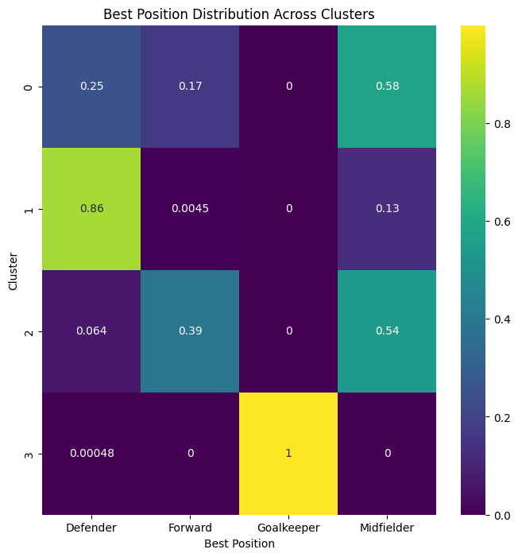

```python
plt.figure(figsize=(8, 8))
sns.heatmap(position_distribution, annot=True, cmap='viridis')
plt.title('Best Position Distribution Across Clusters')
plt.ylabel('Cluster')
plt.xlabel('Best Position')
plt.show()
```

Now we will be visualizing the clusters using PCA

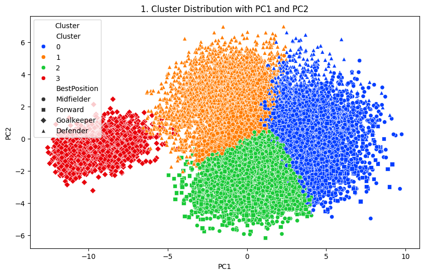

```python
plt.figure(figsize=(10, 6))
sns.scatterplot(x='PC1', y='PC2', hue='Cluster', data=principal_df, palette='bright', style='BestPosition', markers=['o', 's', 'D', '^'])
plt.title('1. Cluster Distribution with PC1 and PC2')
plt.xlabel('PC1')
plt.ylabel('PC2')
plt.legend(title='Cluster')
plt.show()
```

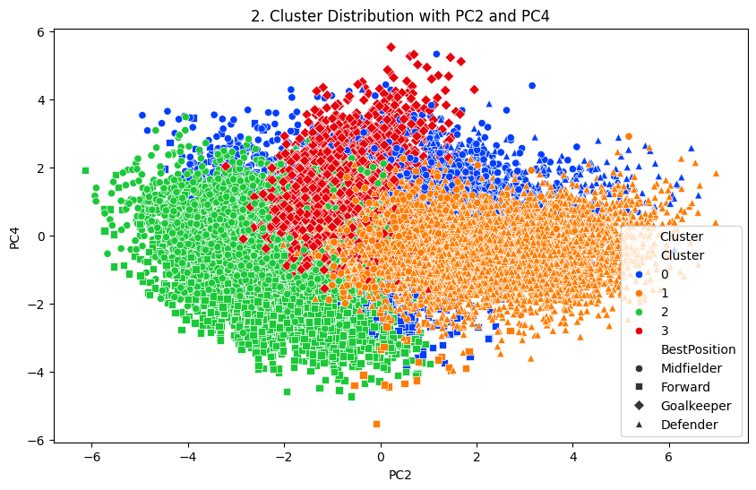

```python
plt.figure(figsize=(10, 6))
sns.scatterplot(x='PC2', y='PC4', hue='Cluster', data=principal_df, palette='bright', style='BestPosition', markers=['o', 's', 'D', '^'])
plt.title('2. Cluster Distribution with PC2 and PC4')
plt.xlabel('PC2')
plt.ylabel('PC4')
plt.legend(title='Cluster')
plt.show()
```

The visualizations clearly illustrate distinct clusters formed from the PCA of player attributes. The cluster distribution across the first two principal components (PC1 and PC2) shows that players can be effectively grouped by attribute similarities, with distinct separations evident. In contrast, the distribution involving (PC2 and PC4) displays some overlap among clusters, suggesting that (PC1 and PC2) are more effective for model training due to their clearer separation of player clusters.

## **4. Model Training**

Finally! let's move onto the fun part of this tutorial...

```python
print(df.columns)
```

```
Index(['Age', 'Height', 'Weight', 'Overall', 'Potential', 'BestPosition',
       'Crossing', 'Finishing', 'HeadingAccuracy', 'ShortPassing', 'Volleys',
       'Dribbling', 'Curve', 'FKAccuracy', 'LongPassing', 'BallControl',
       'Acceleration', 'SprintSpeed', 'Agility', 'Reactions', 'Balance',
       'ShotPower', 'Jumping', 'Stamina', 'Strength', 'LongShots',
       'Aggression', 'Interceptions', 'Positioning', 'Vision', 'Penalties',
       'Composure', 'Marking', 'StandingTackle', 'SlidingTackle', 'GKScore',
       'Cluster'],
      dtype='object')
```

We are going to be training our classification model with Logistic regression and Random Forest classification to see which one gives us the best result.

```python
# Scale features excluding 'BestPosition'
scaler = StandardScaler()
features_scaled = scaler.fit_transform(df.drop(['BestPosition'], axis=1))
```

```python
# Apply PCA to reduce to 2 components
pca = PCA(n_components=2)
X_pca = pca.fit_transform(features_scaled)

# Create a DataFrame with PCA components
X_pca_df = pd.DataFrame(data=X_pca, columns=['PC1','PC2'])

# Add the three additional features to PCA dataframe
additional_features = ['SlidingTackle', 'Finishing', 'HeadingAccuracy']
X_pca_df[additional_features] = df[additional_features]
```

```python
# Encode the target variable
label_encoder = LabelEncoder()
y = label_encoder.fit_transform(df['BestPosition'])
```

```python
# Train-Test Split
X_train, X_test, y_train, y_test = train_test_split(X_pca_df, y, test_size=0.2, random_state=150)
```

```python
# Train Logistic Regression
log_reg = LogisticRegression(max_iter=9000, random_state=150)
log_reg.fit(X_train, y_train)
y_pred_log_reg = log_reg.predict(X_test)

# Train Random Forest
rf = RandomForestClassifier(n_estimators=100, random_state=150)
rf.fit(X_train, y_train)
y_pred_rf = rf.predict(X_test)
```

```python
# Evaluate Models
print("Logistic Regression Accuracy:", accuracy_score(y_test, y_pred_log_reg))
print("Classification Report (Logistic Regression):\n", classification_report(y_test, y_pred_log_reg))
print("Random Forest Accuracy:", accuracy_score(y_test, y_pred_rf))
print("Classification Report (Random Forest):\n", classification_report(y_test, y_pred_rf))
```

```
Logistic Regression Accuracy: 0.854638619201726
Classification Report (Logistic Regression):
               precision    recall  f1-score   support

           0       0.87      0.85      0.86      1264
           1       0.85      0.84      0.85       608
           2       1.00      1.00      1.00       443
           3       0.80      0.82      0.81      1393

    accuracy                           0.85      3708
   macro avg       0.88      0.88      0.88      3708
weighted avg       0.86      0.85      0.85      3708

Random Forest Accuracy: 0.8573354908306364
Classification Report (Random Forest):
               precision    recall  f1-score   support

           0       0.86      0.85      0.86      1264
           1       0.89      0.82      0.85       608
           2       1.00      1.00      1.00       443
           3       0.80      0.83      0.81      1393

    accuracy                           0.86      3708
   macro avg       0.89      0.88      0.88      3708
weighted avg       0.86      0.86      0.86      3708
```

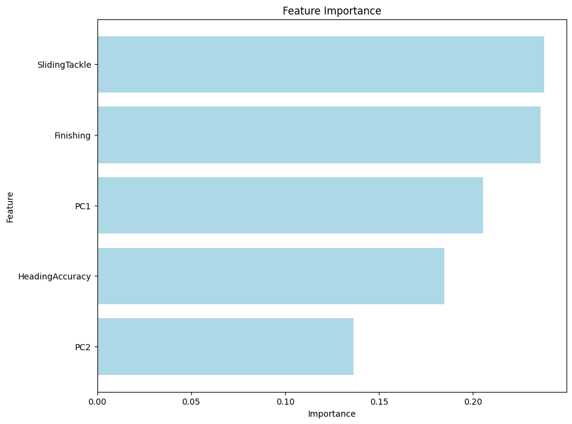

```python
feature_importances = rf.feature_importances_
features = X_train.columns

# Create a DataFrame for easier handling
importance_df = pd.DataFrame({'Feature': features, 'Importance': feature_importances})

# Sort the DataFrame by importance in descending order
importance_df = importance_df.sort_values(by='Importance', ascending=False)

# Plotting
plt.figure(figsize=(10, 8))
plt.barh(importance_df['Feature'], importance_df['Importance'], color='lightblue')
plt.xlabel('Importance')
plt.ylabel('Feature')
plt.title('Feature Importance')
plt.gca().invert_yaxis()  # Invert the y-axis to have the most important feature on top
plt.show()
```

This graph shows us the features that are the most important when it comes to our classification problem.

```python
model = LogisticRegression(C=10, solver='lbfgs', max_iter=5000)

# Perform k-fold cross-validation (k=5 is common, but you can adjust)
cv_scores = cross_val_score(model, X_train, y_train, cv=5, scoring='accuracy')

# Print the results
print("Cross-Validation Scores:", cv_scores)
print("Mean CV Accuracy:", cv_scores.mean())
print("Standard Deviation of CV Accuracy:", cv_scores.std())
```

```
Cross-Validation Scores: [0.85675767 0.85266352 0.8476062  0.84794336 0.85468645]
Mean CV Accuracy: 0.8519314391323212
Standard Deviation of CV Accuracy: 0.003634031973546601
```

```python
from sklearn.ensemble import RandomForestClassifier

best_model = RandomForestClassifier(n_estimators=100, random_state=150)

# Fit the model on the training data
best_model.fit(X_train, y_train)

# Make predictions on the test set
y_test_pred = best_model.predict(X_test)

# Evaluate the model on the test set
test_accuracy = accuracy_score(y_test, y_test_pred)
test_classification_report = classification_report(y_test, y_test_pred)

print("Test Accuracy:", test_accuracy)
print("\nClassification Report (Test Set):\n", test_classification_report)
```

```
Test Accuracy: 0.8573354908306364

Classification Report (Test Set):
               precision    recall  f1-score   support

           0       0.86      0.85      0.86      1264
           1       0.89      0.82      0.85       608
           2       1.00      1.00      1.00       443
           3       0.80      0.83      0.81      1393

    accuracy                           0.86      3708
   macro avg       0.89      0.88      0.88      3708
weighted avg       0.86      0.86      0.86      3708
```